# Statistical interference project2

MS

January 14, 2016

# ToothGrowth analysis

## Overview

This document performs a simple statistic analysis of the “toothgrowth” data package. The Data is first analysed by comparing two observables at a time and combined to an analysis of all three observables.

## Data description

Taken from R Help The response is the length of odontoblasts (teeth) in each of 10 guinea pigs at each of three dose levels of Vitamin C (0.5, 1, and 2 mg) with each of two delivery methods (orange juice or ascorbic acid).

## Analysis

### Data basics

Load the data and show a brief description of the contents.

```r
#Load the data set
data("ToothGrowth")
str(ToothGrowth)
```

```
## 'data.frame':    60 obs. of  3 variables:
##  $ len : num  4.2 11.5 7.3 5.8 6.4 10 11.2 11.2 5.2 7 ...
##  $ supp: Factor w/ 2 levels "OJ","VC": 2 2 2 2 2 2 2 2 2 2 ...
##  $ dose: num  0.5 0.5 0.5 0.5 0.5 0.5 0.5 0.5 0.5 0.5 ...
```

```r
#Seperate out the columns for faster analysis
supp<-ToothGrowth$supp
len<-ToothGrowth$len
dose<-ToothGrowth$dose
```

The data has 60 observations with 3 variables: “len”, “supp” and “dose”. “len” is the length of the tooth, “supp” is the supplementory type as a factor (Orange Juice or Ascorbic Acid), and “dose” is the dosage in milligrams/day.

Lets have a close look at the data

```r
summary(ToothGrowth)
```

```
##       len        supp         dose
##  Min.   : 4.20   OJ:30   Min.   :0.500
##  1st Qu.:13.07   VC:30   1st Qu.:0.500
##  Median :19.25           Median :1.000
##  Mean   :18.81           Mean   :1.167
##  3rd Qu.:25.27           3rd Qu.:2.000
##  Max.   :33.90           Max.   :2.000
```

The tooth length varies from 4.2 to 33.9 with a mean of 18.8. The observations are equally distributed among OJ and VC. Dosage ranges from 0.5 to 2 mg vitmin C, however we can’t see how many are in each group.

```r
dfDose<-as.data.frame(table(dose))
dfDose
```

```
##   dose Freq
## 1  0.5   20
## 2    1   20
## 3    2   20
```

Now we know that there are three different dosages: 0.5, 1 and 2 mg. Each with 20 observations.

### Exploring the dataset using two observations

First we plot all the data using the pairs function with OJ in orange and VC in green.

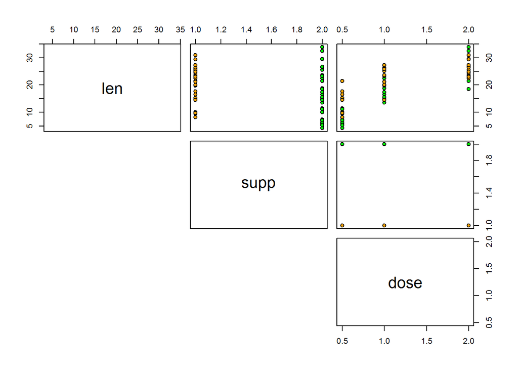

```r
##Call pairs and color according to supp
pairs(ToothGrowth, pch = 21, bg = c("orange","green")[supp], lower.panel=NULL)
```

The plotting of “dose” vs. “supp” does not tell us anything we dont already know. In “supp” vs “len” it seems that OJ has a smaller variance than VC but the averages are not clear. “dose” vs. “len” show a general positive correlation between the dose and the tooth length.

Lets start by exploring the relationship between “supp” and “len” without looking at the dose.

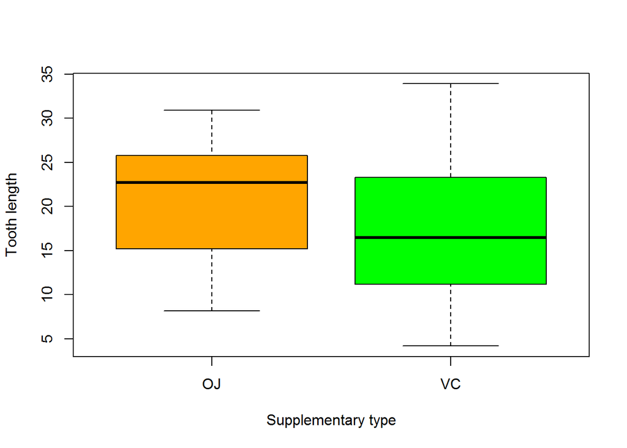

```r
#Plot supp vs len
boxplot(len ~ supp, type = "p", xlab ="Supplementary type", ylab = "Tooth length", col = c("orange","green"))
```

The mean of VC is lower than OJ. But is it significant? The p-value and 95% confidence interval is calculated for a two-sided T-distribution with unequal variables with the null hypothesis that the means are equal.

```r
#Calculating the p value and confidence interval for supp vs len
lensuppP <- t.test(len ~ supp, alt ="two.sided", paired = F, var.equal = F)$p.value
lensuppC <- t.test(len ~ supp, alt ="two.sided", paired = F, var.equal = F)$conf
```

The p value is 0.0606345 and the confidence interval is [-0.1710156, 7.5710156]. As p value > 0.05 we fail to reject the null hypothesis (that the means are equal).

Lets have a look at the “dose” vs “len”“:

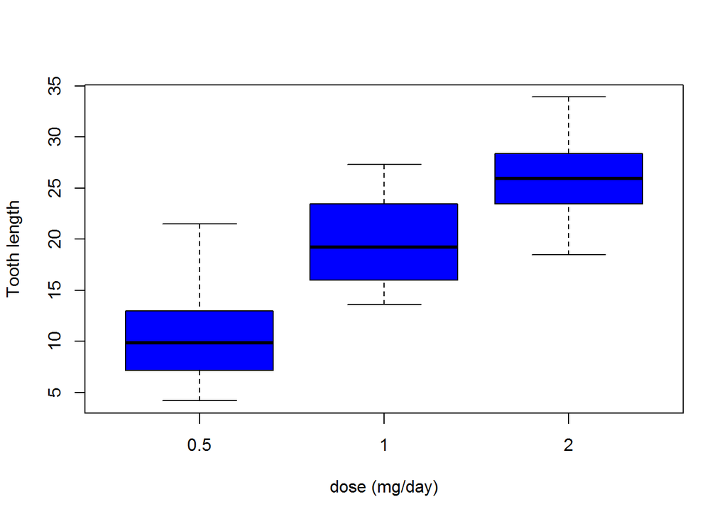

```r
#Plot dose vs len
boxplot(len ~ dose, xlab ="dose (mg/day)", ylab = "Tooth length", col = c("blue"))
```

The tooth length means seem to be positive correlated with the dosage. Lets have a look at the p value using the same parameters as above for all three posibilities

```r
tResults <- NULL
for (i in 1:2) {
    for (j in (i+1):3) {
        doseIndex <- c(i,j)
        dosesTest <- dose %in% unique(dose)[doseIndex]
        pval <- t.test(len[dosesTest] ~ dose[dosesTest], alt ="two.sided", paired = F, var.equal = F)$p.value
        conf <- t.test(len[dosesTest] ~ dose[dosesTest], alt ="two.sided", paired = F, var.equal = F)$conf
        tResults<-as.data.frame(rbind(tResults,cbind(pval,conf[1],conf[2])))
    }
}
rownames(tResults) <- c("0.5 & 1.0|","0.5 & 2.0|","1.0 & 2.0|")
colnames(tResults)<-c("p.value","conf.low","conf.high")
round(tResults,3)
```

```
##            p.value conf.low conf.high
## 0.5 & 1.0|       0  -11.984    -6.276
## 0.5 & 2.0|       0  -18.156   -12.834
## 1.0 & 2.0|       0   -8.996    -3.734
```

```r
p.adjust(tResults$p.value, method = "BH")
```

```
## [1] 1.902451e-07 1.319257e-13 1.906430e-05
```

Yes they do.

Lets plot the length according to dose and supplementary.

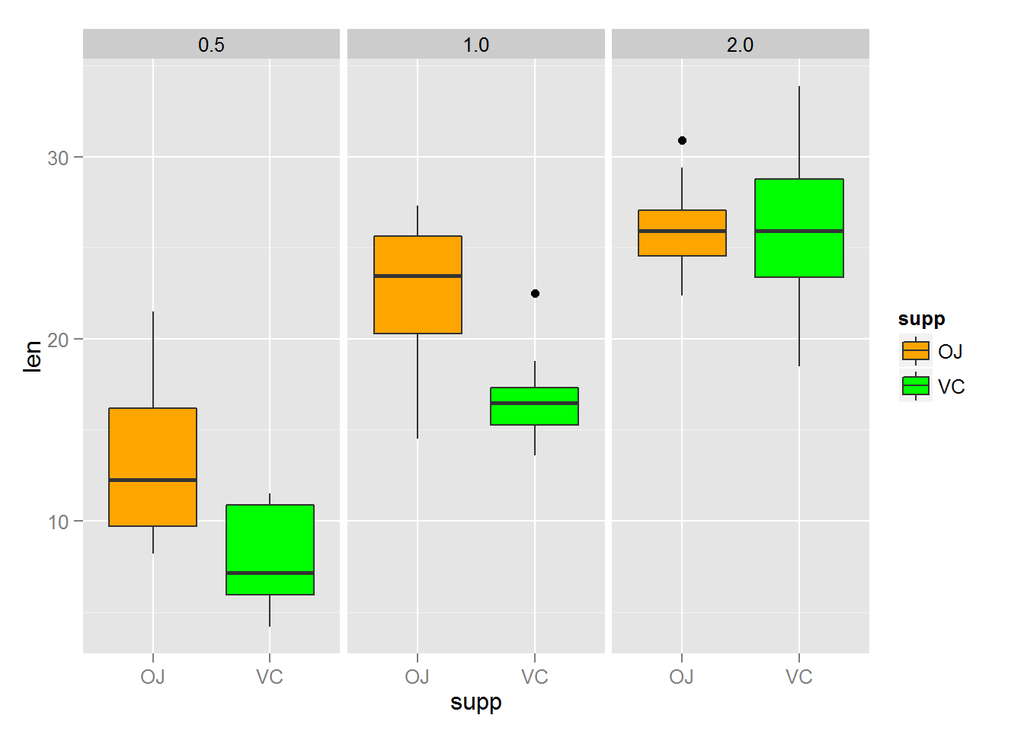

```r
library(ggplot2)
ggplot(aes(x = supp, y = len), data = ToothGrowth) +
    geom_boxplot(aes(fill = supp)) + facet_wrap(~ dose) +
    scale_fill_manual(values=c("Orange","Green"))
```

The mean seems different for the delivery method at concentration 0.5 and 1.0 mg/day, but equal for 2.0 mg/day. Lets calculate the p values and confidence intervals as above.

```r
tResults <- NULL

for (i in (1:3)) {
    dosesTest <- dose %in% unique(dose)[i]
    pval <- t.test(len[dosesTest] ~ supp[dosesTest], alt ="two.sided", paired = F, var.equal = F)$p.value
    conf <- t.test(len[dosesTest] ~ supp[dosesTest], alt ="two.sided", paired = F, var.equal = F)$conf
    tResults<-as.data.frame(rbind(tResults,cbind(pval,conf[1],conf[2])))
}
colnames(tResults)<-c("p.value","conf.low","conf.high")
rownames(tResults) <- unique(dose)
tResults
```

```
##         p.value  conf.low conf.high
## 0.5 0.006358607  1.719057  8.780943
## 1   0.001038376  2.802148  9.057852
## 2   0.963851589 -3.798070  3.638070
```

```r
p.adjust(tResults$p.value, method = "BH")
```

```
## [1] 0.009537910 0.003115128 0.963851589
```

Yes they do.

## Conclusions

This leads to other potential working hypothesis’ that would require more data:

There is a maximum effect of Vitamin C on tooth length that is independent of delivery method

```
In our current data this is achieved at 2.0 mg/mL for both delivery methods and is supported by the fact that there is a difference in delivery method for the low concentrations but not at the highest.
```

The effect of Vitamin C on tooth length depends on the absorption by the gut and hence explains the differences observed for the delivery methods.

```
Needs a completely different data set of Vitamin C absorption by delivery method and should then be correlated with tooth length.
```

### Assumptions

The following assumptions have been made:

1. The poplulations are independent
2. Divided into groups randomly
3. The delivery method does not have other effects on tooth length then Vitamin C (i.e. other ingredients in Orange Juice, which would require a control group of Guinea Pigs receiving Orange Juice without Vitamin C)